```python
#Importing necessary libraries
import numpy as np # linear algebra
import pandas as pd # data processing, CSV file I/O (e.g. pd.read_csv)
import scipy.stats as stats
import warnings
import math
import seaborn as sns
import matplotlib.pyplot as plt
from scipy.stats import pointbiserialr

warnings.filterwarnings("ignore")
```

```python
#Reading the data
data = pd.read_csv('ifood_df.csv')

#Taking a look at the top 5 rows of the data
print("\nFirst 5 Rows:")
data.head()
print("Dataset Overview:")
print(data.info())
```

```
First 5 Rows:
Dataset Overview:
<class 'pandas.core.frame.DataFrame'>
RangeIndex: 2205 entries, 0 to 2204
Data columns (total 39 columns):
 #   Column                Non-Null Count  Dtype
---  ------                --------------  -----
 0   Income                2205 non-null   float64
 1   Kidhome               2205 non-null   int64
 2   Teenhome              2205 non-null   int64
 3   Recency               2205 non-null   int64
 4   MntWines              2205 non-null   int64
 5   MntFruits             2205 non-null   int64
 6   MntMeatProducts       2205 non-null   int64
 7   MntFishProducts       2205 non-null   int64
```

[output cut: 34 more lines]

# EDA

```python
# Summary statistics
print("\nSummary Statistics:")
print(data.describe())

# Check for missing values
missing_values = data.isnull().sum()
print("\nMissing Values:")
print(missing_values[missing_values > 0])
```

```
Summary Statistics:
              Income      Kidhome     Teenhome      Recency     MntWines  \
count    2205.000000  2205.000000  2205.000000  2205.000000  2205.000000
mean    51622.094785     0.442177     0.506576    49.009070   306.164626
std     20713.063826     0.537132     0.544380    28.932111   337.493839
min      1730.000000     0.000000     0.000000     0.000000     0.000000
25%     35196.000000     0.000000     0.000000    24.000000    24.000000
50%     51287.000000     0.000000     0.000000    49.000000   178.000000
75%     68281.000000     1.000000     1.000000    74.000000   507.000000
max    113734.000000     2.000000     2.000000    99.000000  1493.000000

         MntFruits  MntMeatProducts  MntFishProducts  MntSweetProducts  \
count  2205.000000      2205.000000      2205.000000       2205.000000
mean     26.403175       165.312018        37.756463         27.128345
std      39.784484       217.784507        54.824635         41.130468
min       0.000000         0.000000         0.000000          0.000000
25%       2.000000        16.000000         3.000000          1.000000
50%       8.000000        68.000000        12.000000          8.000000
75%      33.000000       232.000000        50.000000         34.000000
max     199.000000      1725.000000       259.000000        262.000000

       MntGoldProds  ...  marital_Together  marital_Widow  education_2n Cycle  \
count   2205.000000  ...       2205.000000    2205.000000         2205.000000
mean      44.057143  ...          0.257596       0.034467            0.089796
std       51.736211  ...          0.437410       0.182467            0.285954
min        0.000000  ...          0.000000       0.000000            0.000000
25%        9.000000  ...          0.000000       0.000000            0.000000
50%       25.000000  ...          0.000000       0.000000            0.000000
75%       56.000000  ...          1.000000       0.000000            0.000000
max      321.000000  ...          1.000000       1.000000            1.000000

       education_Basic  education_Graduation  education_Master  education_PhD  \
count      2205.000000           2205.000000       2205.000000    2205.000000
mean          0.024490              0.504762          0.165079       0.215873
std           0.154599              0.500091          0.371336       0.411520
min           0.000000              0.000000          0.000000       0.000000
25%           0.000000              0.000000          0.000000       0.000000
50%           0.000000              1.000000          0.000000       0.000000
75%           0.000000              1.000000          0.000000       0.000000
max           1.000000              1.000000          1.000000       1.000000

          MntTotal  MntRegularProds  AcceptedCmpOverall
count  2205.000000      2205.000000          2205.00000
mean    562.764626       518.707483             0.29932
std     575.936911       553.847248             0.68044
min       4.000000      -283.000000             0.00000
25%      56.000000        42.000000             0.00000
50%     343.000000       288.000000             0.00000
75%     964.000000       884.000000             0.00000
max    2491.000000      2458.000000             4.00000

[8 rows x 39 columns]

Missing Values:
Series([], dtype: int64)
```

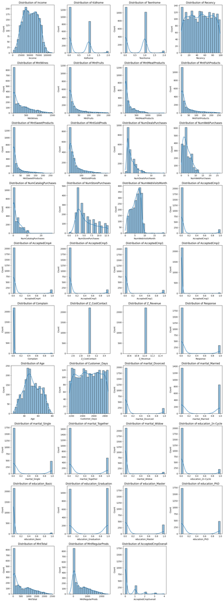

```python
# Select numeric columns
numeric_cols = data.select_dtypes(include=['number']).columns

# Dynamically adjust the grid layout
num_features = len(numeric_cols)
rows = math.ceil(num_features / 4)  # Adjust rows dynamically based on the number of features
cols = min(4, num_features)  # Limit columns to 4

# Plot histograms
fig, axes = plt.subplots(rows, cols, figsize=(15, rows * 4))  # Adjust height dynamically
axes = axes.flatten()  # Flatten in case of multiple rows

for i, col in enumerate(numeric_cols):
    sns.histplot(data[col], bins=20, kde=True, ax=axes[i])
    axes[i].set_title(f"Distribution of {col}")

# Remove empty subplots
for i in range(num_features, len(axes)):
    fig.delaxes(axes[i])

plt.tight_layout()
plt.show()
```

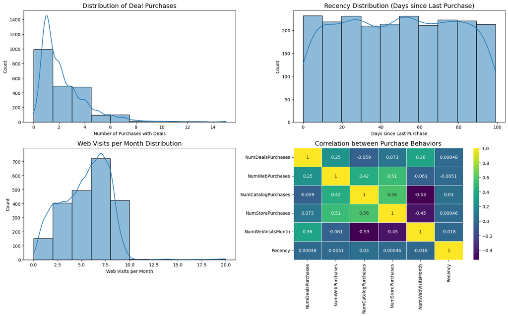

```python
# 3.3 Purchase Behavior Analysis
plt.figure(figsize=(16, 10))

plt.subplot(2, 2, 1)
sns.histplot(data['NumDealsPurchases'], kde=True, bins=10)
plt.title('Distribution of Deal Purchases', fontsize=14)
plt.xlabel('Number of Purchases with Deals')
plt.ylabel('Count')

plt.subplot(2, 2, 2)
sns.histplot(data['Recency'], kde=True, bins=10)
plt.title('Recency Distribution (Days since Last Purchase)', fontsize=14)
plt.xlabel('Days since Last Purchase')
plt.ylabel('Count')

plt.subplot(2, 2, 3)
sns.histplot(data['NumWebVisitsMonth'], kde=True, bins=10)
plt.title('Web Visits per Month Distribution', fontsize=14)
plt.xlabel('Web Visits per Month')
plt.ylabel('Count')

plt.subplot(2, 2, 4)
# Correlation between purchase behavior variables
purchase_behavior_cols = ['NumDealsPurchases', 'NumWebPurchases', 'NumCatalogPurchases',
                          'NumStorePurchases', 'NumWebVisitsMonth', 'Recency']
purchase_corr = data[purchase_behavior_cols].corr()
sns.heatmap(purchase_corr, annot=True, cmap='viridis', linewidths=0.5)
plt.title('Correlation between Purchase Behaviors', fontsize=14)

plt.tight_layout()
```

```python
# Selected features for deeper analysis
selected_features = [
    "Income", "MntWines", "MntFruits", "MntMeatProducts", "MntFishProducts",
    "MntSweetProducts", "MntGoldProds", "NumWebPurchases", "NumCatalogPurchases",
    "NumStorePurchases", "AcceptedCmpOverall", "Age"
]

# Compute skewness & kurtosis
skew_kurtosis = pd.DataFrame({
    "Feature": selected_features,
    "Skewness": [stats.skew(data[col].dropna()) for col in selected_features],
    "Kurtosis": [stats.kurtosis(data[col].dropna()) for col in selected_features]
})

print(skew_kurtosis)
```

```
                Feature  Skewness  Kurtosis
0                Income  0.013155 -0.848363
1              MntWines  1.166123  0.570886
2             MntFruits  2.097852  4.038878
3       MntMeatProducts  1.817678  3.238057
4       MntFishProducts  1.910727  3.046692
5      MntSweetProducts  2.096927  4.067864
6          MntGoldProds  1.833219  3.133915
7       NumWebPurchases  1.200559  4.089808
8   NumCatalogPurchases  1.367191  3.200419
9     NumStorePurchases  0.706479 -0.636527
10   AcceptedCmpOverall  2.717597  7.953959
11                  Age  0.089880 -0.797949
```

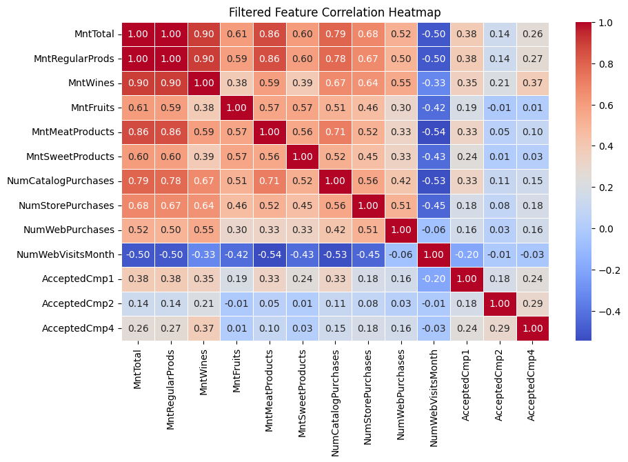

```python
# Selected highly correlated features
selected_features = [
    "MntTotal", "MntRegularProds", "MntWines", "MntFruits",
    "MntMeatProducts", "MntSweetProducts", "NumCatalogPurchases",
    "NumStorePurchases", "NumWebPurchases", "NumWebVisitsMonth",
    "AcceptedCmp1", "AcceptedCmp2", "AcceptedCmp4"
]

# Compute correlation matrix for selected features
corr_matrix_selected = data[selected_features].corr()

# Plot heatmap
plt.figure(figsize=(10, 6))
sns.heatmap(corr_matrix_selected, annot=True, cmap="coolwarm", fmt=".2f", linewidths=0.5)

plt.title("Filtered Feature Correlation Heatmap")
plt.show()
```

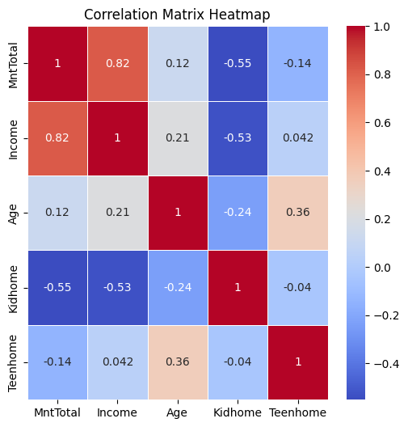

```python
cols_demographics = ['Income','Age']
cols_children = ['Kidhome', 'Teenhome']
cols_marital = ['marital_Divorced', 'marital_Married','marital_Single', 'marital_Together', 'marital_Widow']
cols_mnt = ['MntTotal', 'MntRegularProds','MntWines', 'MntFruits', 'MntMeatProducts', 'MntFishProducts', 'MntSweetProducts', 'MntGoldProds']
cols_communication = ['Complain', 'Response', 'Customer_Days']
cols_campaigns = ['AcceptedCmpOverall', 'AcceptedCmp1', 'AcceptedCmp2', 'AcceptedCmp3', 'AcceptedCmp4', 'AcceptedCmp5']
cols_source_of_purchase = ['NumDealsPurchases', 'NumWebPurchases','NumCatalogPurchases', 'NumStorePurchases', 'NumWebVisitsMonth']
cols_education = ['education_2n Cycle', 'education_Basic', 'education_Graduation', 'education_Master', 'education_PhD']

corr_matrix = data[['MntTotal']+cols_demographics+cols_children].corr()
plt.figure(figsize=(6,6))
sns.heatmap(corr_matrix, annot=True, cmap='coolwarm', linewidths=0.5)
plt.title('Correlation Matrix Heatmap')
plt.show()
```

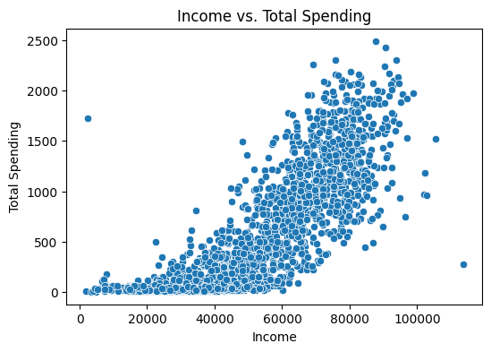

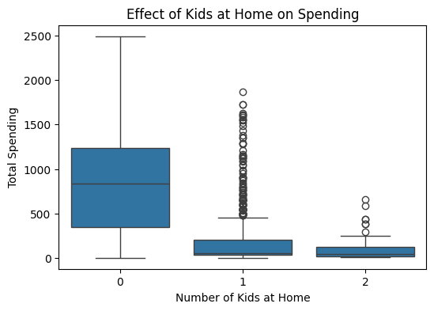

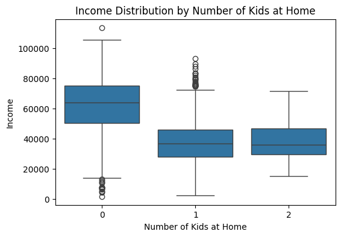

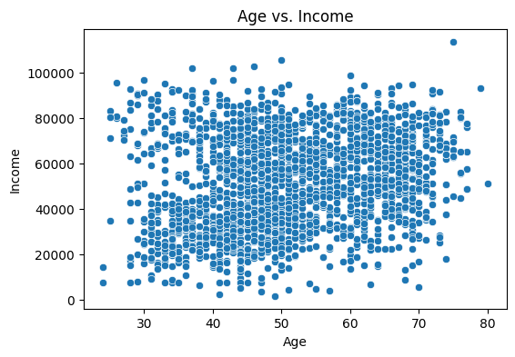

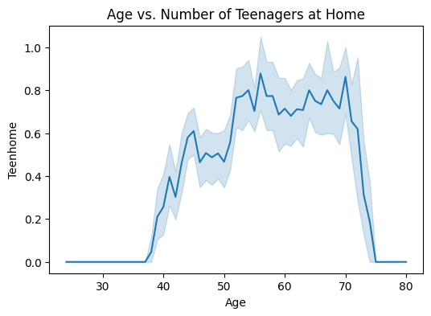

```python
# Scatter plot for Income vs. MntTotal
plt.figure(figsize=(6, 4))
sns.scatterplot(x=data['Income'], y=data['MntTotal'])
plt.xlabel("Income")
plt.ylabel("Total Spending")
plt.title("Income vs. Total Spending")
plt.show()

# Boxplot for Kidhome vs. Total Spending
plt.figure(figsize=(6, 4))
sns.boxplot(x=data['Kidhome'], y=data['MntTotal'])
plt.xlabel("Number of Kids at Home")
plt.ylabel("Total Spending")
plt.title("Effect of Kids at Home on Spending")
plt.show()

# Boxplot for Kidhome vs. Income
plt.figure(figsize=(6, 4))
sns.boxplot(x=data['Kidhome'], y=data['Income'])
plt.xlabel("Number of Kids at Home")
plt.ylabel("Income")
plt.title("Income Distribution by Number of Kids at Home")
plt.show()

# Scatter plot for Age vs. Income
plt.figure(figsize=(6, 4))
sns.scatterplot(x=data['Age'], y=data['Income'])
plt.xlabel("Age")
plt.ylabel("Income")
plt.title("Age vs. Income")
plt.show()

# Line plot for Age vs. Teenhome
plt.figure(figsize=(6, 4))
sns.lineplot(x=data['Age'], y=data['Teenhome'])
plt.xlabel("Age")
plt.ylabel("Teenhome")
plt.title("Age vs. Number of Teenagers at Home")
plt.show()
```

```python
df = pd.read_csv('ifood_df.csv')
df.head()
```

|  | Income | Kidhome | Teenhome | Recency | MntWines | MntFruits | MntMeatProducts | MntFishProducts | MntSweetProducts | MntGoldProds | ... | marital_Together | marital_Widow | education_2n Cycle | education_Basic | education_Graduation | education_Master | education_PhD | MntTotal | MntRegularProds | AcceptedCmpOverall |
| --- | --- | --- | --- | --- | --- | --- | --- | --- | --- | --- | --- | --- | --- | --- | --- | --- | --- | --- | --- | --- | --- |
| 0 | 58138.0 | 0 | 0 | 58 | 635 | 88 | 546 | 172 | 88 | 88 | ... | 0 | 0 | 0 | 0 | 1 | 0 | 0 | 1529 | 1441 | 0 |
| 1 | 46344.0 | 1 | 1 | 38 | 11 | 1 | 6 | 2 | 1 | 6 | ... | 0 | 0 | 0 | 0 | 1 | 0 | 0 | 21 | 15 | 0 |
| 2 | 71613.0 | 0 | 0 | 26 | 426 | 49 | 127 | 111 | 21 | 42 | ... | 1 | 0 | 0 | 0 | 1 | 0 | 0 | 734 | 692 | 0 |
| 3 | 26646.0 | 1 | 0 | 26 | 11 | 4 | 20 | 10 | 3 | 5 | ... | 1 | 0 | 0 | 0 | 1 | 0 | 0 | 48 | 43 | 0 |
| 4 | 58293.0 | 1 | 0 | 94 | 173 | 43 | 118 | 46 | 27 | 15 | ... | 0 | 0 | 0 | 0 | 0 | 0 | 1 | 407 | 392 | 0 |

5 rows × 39 columns

```python
# Check Outlier
Q1 = data['MntTotal'].quantile(0.25)
Q3 = data['MntTotal'].quantile(0.75)
IQR = Q3 - Q1
lower_bound = Q1 - 1.5 * IQR
upper_bound = Q3 + 1.5 * IQR
outliers = data[(df['MntTotal'] < lower_bound) | (df['MntTotal'] > upper_bound)]
outliers.head()
```

|  | Income | Kidhome | Teenhome | Recency | MntWines | MntFruits | MntMeatProducts | MntFishProducts | MntSweetProducts | MntGoldProds | ... | marital_Together | marital_Widow | education_2n Cycle | education_Basic | education_Graduation | education_Master | education_PhD | MntTotal | MntRegularProds | AcceptedCmpOverall |
| --- | --- | --- | --- | --- | --- | --- | --- | --- | --- | --- | --- | --- | --- | --- | --- | --- | --- | --- | --- | --- | --- |
| 1159 | 90638.0 | 0 | 0 | 29 | 1156 | 120 | 915 | 94 | 144 | 96 | ... | 0 | 0 | 0 | 0 | 0 | 1 | 0 | 2429 | 2333 | 1 |
| 1467 | 87679.0 | 0 | 0 | 62 | 1259 | 172 | 815 | 97 | 148 | 33 | ... | 1 | 0 | 0 | 0 | 1 | 0 | 0 | 2491 | 2458 | 3 |
| 1547 | 90638.0 | 0 | 0 | 29 | 1156 | 120 | 915 | 94 | 144 | 96 | ... | 0 | 0 | 0 | 0 | 0 | 1 | 0 | 2429 | 2333 | 1 |

3 rows × 39 columns

```python
# Drop Outlier
data = data[(df['MntTotal'] > lower_bound) & (df['MntTotal'] < upper_bound)]
data.describe()
```

|  | Income | Kidhome | Teenhome | Recency | MntWines | MntFruits | MntMeatProducts | MntFishProducts | MntSweetProducts | MntGoldProds | ... | marital_Together | marital_Widow | education_2n Cycle | education_Basic | education_Graduation | education_Master | education_PhD | MntTotal | MntRegularProds | AcceptedCmpOverall |
| --- | --- | --- | --- | --- | --- | --- | --- | --- | --- | --- | --- | --- | --- | --- | --- | --- | --- | --- | --- | --- | --- |
| count | 2202.000000 | 2202.000000 | 2202.000000 | 2202.000000 | 2202.000000 | 2202.000000 | 2202.000000 | 2202.000000 | 2202.000000 | 2202.000000 | ... | 2202.000000 | 2202.000000 | 2202.000000 | 2202.000000 | 2202.000000 | 2202.000000 | 2202.000000 | 2202.000000 | 2202.000000 | 2202.000000 |
| mean | 51570.283379 | 0.442779 | 0.507266 | 49.021344 | 304.960036 | 26.252044 | 164.336058 | 37.678474 | 26.967302 | 44.014986 | ... | 0.257493 | 0.034514 | 0.089918 | 0.024523 | 0.504995 | 0.164396 | 0.216167 | 560.193915 | 516.178928 | 0.297457 |
| std | 20679.438848 | 0.537250 | 0.544429 | 28.944211 | 336.135586 | 39.589747 | 216.312982 | 54.821185 | 40.926101 | 51.747221 | ... | 0.437353 | 0.182587 | 0.286130 | 0.154702 | 0.500089 | 0.370719 | 0.411723 | 572.096830 | 549.962471 | 0.678134 |
| min | 1730.000000 | 0.000000 | 0.000000 | 0.000000 | 0.000000 | 0.000000 | 0.000000 | 0.000000 | 0.000000 | 0.000000 | ... | 0.000000 | 0.000000 | 0.000000 | 0.000000 | 0.000000 | 0.000000 | 0.000000 | 4.000000 | -283.000000 | 0.000000 |
| 25% | 35182.500000 | 0.000000 | 0.000000 | 24.000000 | 24.000000 | 2.000000 | 16.000000 | 3.000000 | 1.000000 | 9.000000 | ... | 0.000000 | 0.000000 | 0.000000 | 0.000000 | 0.000000 | 0.000000 | 0.000000 | 56.000000 | 42.000000 | 0.000000 |
| 50% | 51258.500000 | 0.000000 | 0.000000 | 49.000000 | 176.500000 | 8.000000 | 68.000000 | 12.000000 | 8.000000 | 25.000000 | ... | 0.000000 | 0.000000 | 0.000000 | 0.000000 | 1.000000 | 0.000000 | 0.000000 | 342.500000 | 288.000000 | 0.000000 |
| 75% | 68146.500000 | 1.000000 | 1.000000 | 74.000000 | 505.000000 | 33.000000 | 230.750000 | 50.000000 | 33.000000 | 56.000000 | ... | 1.000000 | 0.000000 | 0.000000 | 0.000000 | 1.000000 | 0.000000 | 0.000000 | 962.000000 | 883.000000 | 0.000000 |
| max | 113734.000000 | 2.000000 | 2.000000 | 99.000000 | 1493.000000 | 199.000000 | 1725.000000 | 259.000000 | 262.000000 | 321.000000 | ... | 1.000000 | 1.000000 | 1.000000 | 1.000000 | 1.000000 | 1.000000 | 1.000000 | 2304.000000 | 2259.000000 | 4.000000 |

8 rows × 39 columns

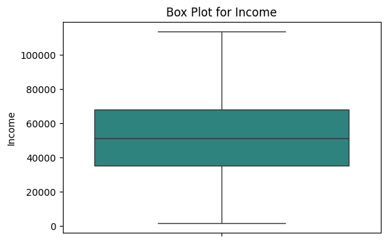

```python
plt.figure(figsize=(6, 4))
sns.boxplot(data=df, y='Income', palette='viridis')
plt.title('Box Plot for Income')
plt.ylabel('Income')
plt.show()
```

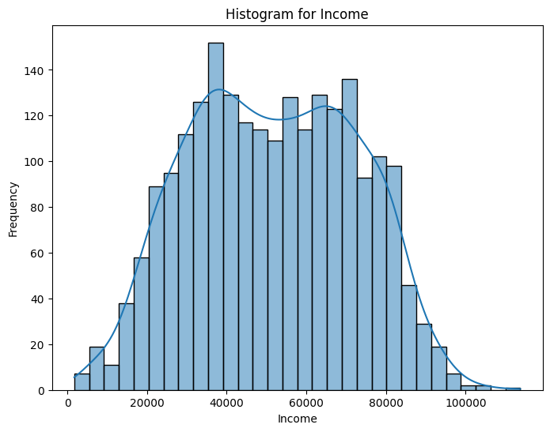

```python
plt.figure(figsize=(8, 6))
sns.histplot(data=df, x='Income', bins=30, kde=True)
plt.title('Histogram for Income')
plt.xlabel('Income')
plt.ylabel('Frequency')
plt.show()
```

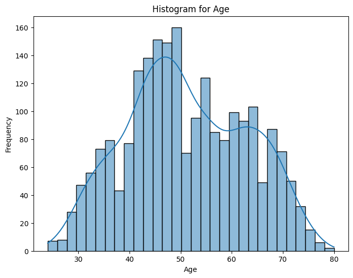

```python
plt.figure(figsize=(8, 6))
sns.histplot(data=df, x='Age', bins=30, kde=True)
plt.title('Histogram for Age')
plt.xlabel('Age')
plt.ylabel('Frequency')
plt.show()
```

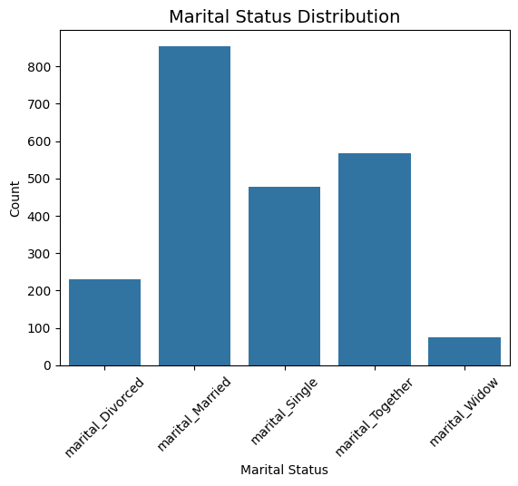

```python
# Marital status
marital_cols = [col for col in df.columns if col.startswith('marital_')]
if marital_cols:
    marital_data = df[marital_cols].sum().reset_index()
    marital_data.columns = ['Status', 'Count']
    sns.barplot(x='Status', y='Count', data=marital_data)
    plt.title('Marital Status Distribution', fontsize=14)
    plt.xticks(rotation=45)
    plt.xlabel('Marital Status')
    plt.ylabel('Count')
elif 'Marital_Status' in df.columns:
    marital_counts = df['Marital_Status'].value_counts().reset_index()
    marital_counts.columns = ['Status', 'Count']
    sns.barplot(x='Status', y='Count', data=marital_counts)
    plt.title('Marital Status Distribution', fontsize=14)
    plt.xticks(rotation=45)
    plt.xlabel('Marital Status')
    plt.ylabel('Count')
```

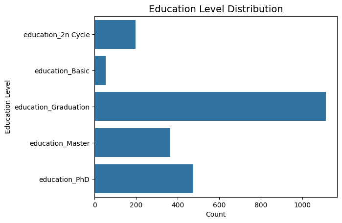

```python
# Education level
education_cols = [col for col in df.columns if col.startswith('education_')]
if education_cols:
    education_data = df[education_cols].sum().reset_index()
    education_data.columns = ['Education', 'Count']
    sns.barplot(x='Count', y='Education', data=education_data)
    plt.title('Education Level Distribution', fontsize=14)
    plt.xlabel('Count')
    plt.ylabel('Education Level')
elif 'Education' in df.columns:
    education_counts = df['Education'].value_counts().reset_index()
    education_counts.columns = ['Education', 'Count']
    sns.barplot(x='Count', y='Education', data=education_counts)
    plt.title('Education Level Distribution', fontsize=14)
    plt.xlabel('Count')
    plt.ylabel('Education Level')
```

```python
print("Skewness: %f" % df['Age'].skew())
print("Kurtosis: %f" % df['Age'].kurt())
```

```
Skewness: 0.089941
Kurtosis: -0.797036
```

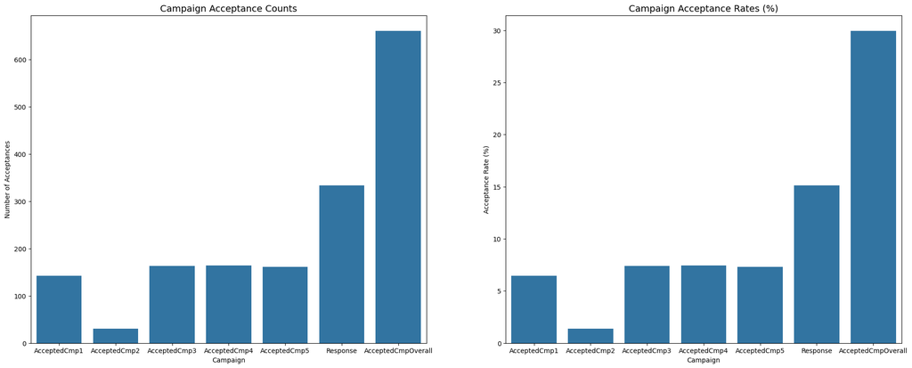

```python
# 3.4 Campaign Performance Analysis
plt.figure(figsize=(24, 20))

plt.subplot(2, 2, 1)
campaign_acceptance = df[campaign_cols].sum().reset_index()
campaign_acceptance.columns = ['Campaign', 'Acceptance Count']
sns.barplot(x='Campaign', y='Acceptance Count', data=campaign_acceptance)
plt.title('Campaign Acceptance Counts', fontsize=14)
plt.xlabel('Campaign')
plt.ylabel('Number of Acceptances')

plt.subplot(2, 2, 2)
# Calculate acceptance rate for each campaign
total_customers = len(df)
campaign_acceptance['Acceptance Rate'] = campaign_acceptance['Acceptance Count'] / total_customers * 100
sns.barplot(x='Campaign', y='Acceptance Rate', data=campaign_acceptance)
plt.title('Campaign Acceptance Rates (%)', fontsize=14)
plt.xlabel('Campaign')
plt.ylabel('Acceptance Rate (%)')
```

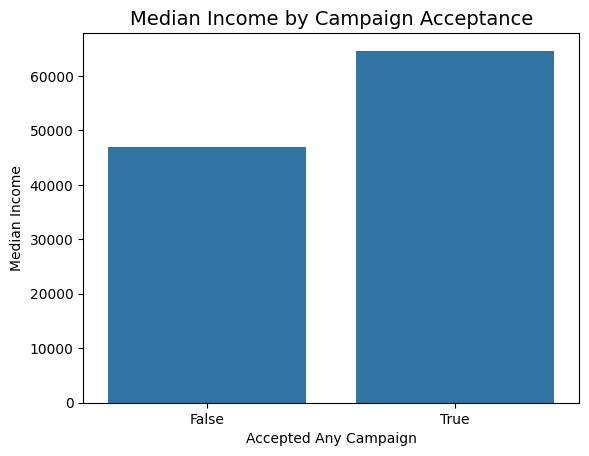

```python
# Relationship between income and campaign acceptance
df['AnyAcceptance'] = df[['AcceptedCmp1', 'AcceptedCmp2', 'AcceptedCmp3',
                          'AcceptedCmp4', 'AcceptedCmp5', 'Response']].sum(axis=1) > 0
campaign_income = df.groupby('AnyAcceptance')['Income'].median().reset_index()
sns.barplot(x='AnyAcceptance', y='Income', data=campaign_income)
plt.title('Median Income by Campaign Acceptance', fontsize=14)
plt.xlabel('Accepted Any Campaign')
plt.ylabel('Median Income')
```

# Model 1

```python
print(df.describe())

# Calculate total spending per customer across all categories
df['TotalSpent'] = df[['MntFishProducts', 'MntMeatProducts', 'MntFruits',
                       'MntSweetProducts', 'MntWines', 'MntGoldProds']].sum(axis=1)

# Calculate average spending per product category
avg_spending = df[['MntFishProducts', 'MntMeatProducts', 'MntFruits',
                   'MntSweetProducts', 'MntWines', 'MntGoldProds']].mean()

print("Average spending per category:", avg_spending)
```

```
              Income      Kidhome     Teenhome      Recency     MntWines  \
count    2205.000000  2205.000000  2205.000000  2205.000000  2205.000000
mean    51622.094785     0.442177     0.506576    49.009070   306.164626
std     20713.063826     0.537132     0.544380    28.932111   337.493839
min      1730.000000     0.000000     0.000000     0.000000     0.000000
25%     35196.000000     0.000000     0.000000    24.000000    24.000000
50%     51287.000000     0.000000     0.000000    49.000000   178.000000
75%     68281.000000     1.000000     1.000000    74.000000   507.000000
max    113734.000000     2.000000     2.000000    99.000000  1493.000000

         MntFruits  MntMeatProducts  MntFishProducts  MntSweetProducts  \
count  2205.000000      2205.000000      2205.000000       2205.000000
mean     26.403175       165.312018        37.756463         27.128345
std      39.784484       217.784507        54.824635         41.130468
min       0.000000         0.000000         0.000000          0.000000
25%       2.000000        16.000000         3.000000          1.000000
50%       8.000000        68.000000        12.000000          8.000000
75%      33.000000       232.000000        50.000000         34.000000
max     199.000000      1725.000000       259.000000        262.000000

       MntGoldProds  ...  marital_Together  marital_Widow  education_2n Cycle  \
count   2205.000000  ...       2205.000000    2205.000000         2205.000000
mean      44.057143  ...          0.257596       0.034467            0.089796
std       51.736211  ...          0.437410       0.182467            0.285954
min        0.000000  ...          0.000000       0.000000            0.000000
25%        9.000000  ...          0.000000       0.000000            0.000000
50%       25.000000  ...          0.000000       0.000000            0.000000
75%       56.000000  ...          1.000000       0.000000            0.000000
max      321.000000  ...          1.000000       1.000000            1.000000

       education_Basic  education_Graduation  education_Master  education_PhD  \
count      2205.000000           2205.000000       2205.000000    2205.000000
mean          0.024490              0.504762          0.165079       0.215873
std           0.154599              0.500091          0.371336       0.411520
min           0.000000              0.000000          0.000000       0.000000
25%           0.000000              0.000000          0.000000       0.000000
50%           0.000000              1.000000          0.000000       0.000000
75%           0.000000              1.000000          0.000000       0.000000
max           1.000000              1.000000          1.000000       1.000000

          MntTotal  MntRegularProds  AcceptedCmpOverall
count  2205.000000      2205.000000          2205.00000
mean    562.764626       518.707483             0.29932
std     575.936911       553.847248             0.68044
min       4.000000      -283.000000             0.00000
25%      56.000000        42.000000             0.00000
50%     343.000000       288.000000             0.00000
75%     964.000000       884.000000             0.00000
max    2491.000000      2458.000000             4.00000

[8 rows x 39 columns]
Average spending per category: MntFishProducts      37.756463
MntMeatProducts     165.312018
MntFruits            26.403175
MntSweetProducts     27.128345
MntWines            306.164626
MntGoldProds         44.057143
dtype: float64
```

```python
from sklearn.preprocessing import StandardScaler

# Feature selection
features = ['Income', 'Age', 'TotalSpent', 'NumDealsPurchases', 'NumCatalogPurchases',
            'NumStorePurchases', 'NumWebPurchases', 'NumWebVisitsMonth', 'Recency']
X = df[features]

# Scaling the data
scaler = StandardScaler()
X_scaled = scaler.fit_transform(X)
```

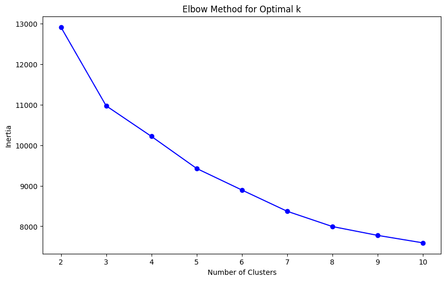

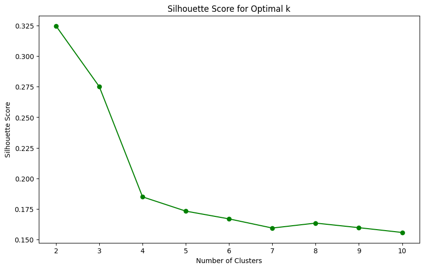

```python
import matplotlib.pyplot as plt
from sklearn.cluster import KMeans
from sklearn.metrics import silhouette_score

# Elbow method and silhouette score
inertia = []
sil_scores = []
k_range = range(2, 11)

for k in k_range:
    kmeans = KMeans(n_clusters=k, random_state=42)
    kmeans.fit(X_scaled)
    inertia.append(kmeans.inertia_)
    sil_scores.append(silhouette_score(X_scaled, kmeans.labels_))

# Plot Elbow Method
plt.figure(figsize=(10, 6))
plt.plot(k_range, inertia, marker='o', color='b', label='Inertia (Elbow Method)')
plt.title('Elbow Method for Optimal k')
plt.xlabel('Number of Clusters')
plt.ylabel('Inertia')
plt.show()

# Plot Silhouette Score
plt.figure(figsize=(10, 6))
plt.plot(k_range, sil_scores, marker='o', color='g', label='Silhouette Score')
plt.title('Silhouette Score for Optimal k')
plt.xlabel('Number of Clusters')
plt.ylabel('Silhouette Score')
plt.show()
```

```python
optimal_k = 4
kmeans = KMeans(n_clusters=optimal_k, random_state=42)
df['Cluster'] = kmeans.fit_predict(X_scaled)

# Check cluster centers
centroids = kmeans.cluster_centers_
print("Cluster Centers:", centroids)
```

```
Cluster Centers: [[ 1.11691643  0.09831157  1.17487891 -0.51998751  1.12220157  0.82485768
   0.3713957  -1.00085018  0.02200737]
 [-1.02345087 -0.76317981 -0.86350738 -0.16883433 -0.77393344 -0.86354893
  -0.73702382  0.6815047  -0.14132895]
 [ 0.20240149  0.26231963  0.17485533  1.10177411  0.02278026  0.51755497
   1.0305937   0.46566522 -0.03670096]
 [-0.45956236  0.74796593 -0.78190194 -0.22612945 -0.65000368 -0.62234249
  -0.70697496 -0.01052789  0.23821249]]
```

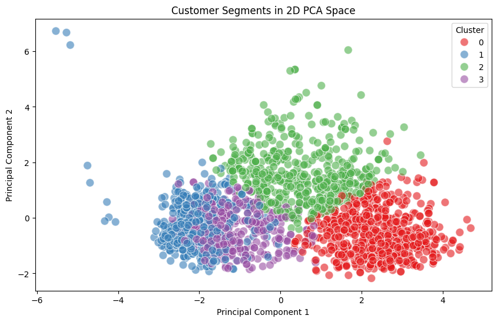

```python
from sklearn.decomposition import PCA
import seaborn as sns

# Perform PCA to reduce data to 2 dimensions
pca = PCA(n_components=2)
X_pca = pca.fit_transform(X_scaled)

# Plot the clusters in 2D PCA space
plt.figure(figsize=(10, 6))
sns.scatterplot(x=X_pca[:, 0], y=X_pca[:, 1], hue=df['Cluster'], palette='Set1', s=100, alpha=0.6)
plt.title('Customer Segments in 2D PCA Space')
plt.xlabel('Principal Component 1')
plt.ylabel('Principal Component 2')
plt.show()
```

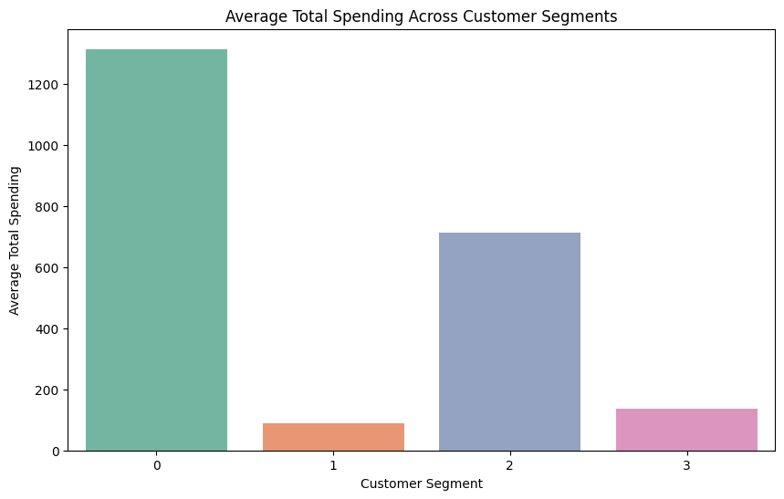

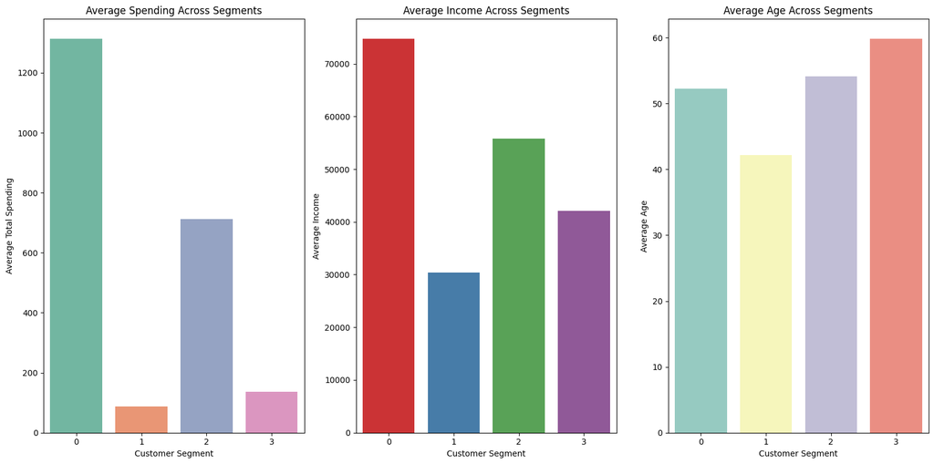

```python
plt.figure(figsize=(10, 6))
sns.barplot(data=df, x='Cluster', y='TotalSpent', estimator='mean', ci=None, palette='Set2')

# Title and labels
plt.title('Average Total Spending Across Customer Segments')
plt.xlabel('Customer Segment')
plt.ylabel('Average Total Spending')
plt.show()

# Set the size of the plot
plt.figure(figsize=(16, 8))

# Plot for Average Spending (TotalSpent)
plt.subplot(1, 3, 1)  # 1 row, 3 columns, first subplot
sns.barplot(data=df, x='Cluster', y='TotalSpent', estimator='mean', ci=None, palette='Set2')
plt.title('Average Spending Across Segments')
plt.xlabel('Customer Segment')
plt.ylabel('Average Total Spending')

# Plot for Average Income
plt.subplot(1, 3, 2)  # 1 row, 3 columns, second subplot
sns.barplot(data=df, x='Cluster', y='Income', estimator='mean', ci=None, palette='Set1')
plt.title('Average Income Across Segments')
plt.xlabel('Customer Segment')
plt.ylabel('Average Income')

# Plot for Average Age
plt.subplot(1, 3, 3)  # 1 row, 3 columns, third subplot
sns.barplot(data=df, x='Cluster', y='Age', estimator='mean', ci=None, palette='Set3')
plt.title('Average Age Across Segments')
plt.xlabel('Customer Segment')
plt.ylabel('Average Age')

# Adjust layout and show the plot
plt.tight_layout()
plt.show()
```

```python
cluster_summary = df.groupby('Cluster').agg({
    'Income': ['mean', 'std'],
    'Age': ['mean', 'std'],
    'TotalSpent': ['mean', 'std'],
    'NumDealsPurchases': ['mean', 'std'],
    'NumCatalogPurchases': ['mean', 'std'],
    'NumStorePurchases': ['mean', 'std'],
    'NumWebPurchases': ['mean', 'std'],
    'NumWebVisitsMonth': ['mean', 'std'],
    'Recency': ['mean', 'std'],
}).reset_index()

# Show the cluster profiling results
print(cluster_summary)
```

```
  Cluster        Income                      Age              TotalSpent  \
                   mean           std       mean        std         mean
0       0  74751.609610   9927.514925  52.246246  13.027421  1313.557057
1       1  30428.099071  10672.059522  42.164087   6.960866    87.388545
2       2  55813.498990  10918.298745  54.165657   9.684331   712.004040
3       3  42105.309045  11928.124225  59.849246   7.772741   136.477387

              NumDealsPurchases           NumCatalogPurchases            \
          std              mean       std                mean       std
0  440.107694          1.337838  0.967896            5.785285  2.509619
1   83.334904          2.000000  1.406519            0.479876  0.729488
2  342.010737          4.395960  2.300498            2.709091  1.713314
3  126.324931          1.891960  1.019154            0.826633  0.961524

  NumStorePurchases           NumWebPurchases           NumWebVisitsMonth  \
               mean       std            mean       std              mean
0          8.496997  2.859227        5.117117  2.039042          2.921922
1          3.024768  0.954470        2.083591  1.262142          6.981424
2          7.501010  2.634922        6.921212  2.612616          6.460606
3          3.806533  1.485533        2.165829  1.236570          5.311558

               Recency
        std       mean        std
0  1.700924  49.645646  29.372033
1  1.913549  44.921053  28.380717
2  1.483364  47.947475  27.874961
3  1.745355  55.899497  29.148278
```

Insights:

Cluster 0 could represent high-income customers who spend a lot on premium products.

Cluster 2 could be active online shoppers who engage with the website frequently.

Cluster 3 might represent older customers with low spending habits.

Recommendations:

For Cluster 0, offer premium products and loyalty programs to retain high-spending customers.

For Cluster 1, provide personalized discount offers and promotions.

For Cluster 2, focus on engaging them further with new arrivals and promotions via email or online ads.

For Cluster 3, consider offering products that fit their age group and cater to less frequent shopping behaviors.

# Model 2

```python
#Reading the data
data = pd.read_csv('ifood_df.csv')
```

```python
def get_marital_status(row):
    if row['marital_Divorced'] == 1:
        return 'Divorced'
    elif row['marital_Married'] == 1:
        return 'Married'
    elif row['marital_Single'] == 1:
        return 'Single'
    elif row['marital_Together'] == 1:
        return 'Together'
    elif row['marital_Widow'] == 1:
        return 'Widow'
    else:
        return 'Unknown'
data['Marital'] = data.apply(get_marital_status, axis=1)
```

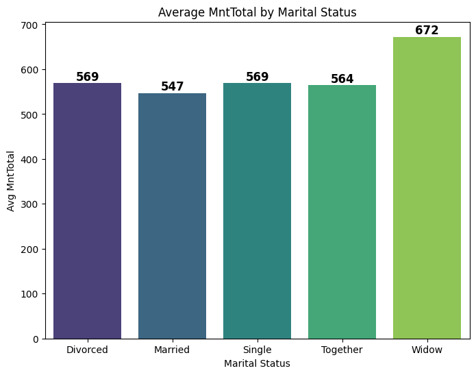

```python
import matplotlib.pyplot as plt
import seaborn as sns
# Create a new column for marital status
data['Marital'] = data.apply(get_marital_status, axis=1)

# Compute mean total spending by marital status
marital_spending = data.groupby("Marital")["MntTotal"].mean().reset_index()

# Plot with exact values on bars
plt.figure(figsize=(8, 6))
ax = sns.barplot(x="Marital", y="MntTotal", data=marital_spending, palette="viridis")

# Annotate bars with values
for p in ax.patches:
    ax.annotate(f'{p.get_height():.0f}',
                (p.get_x() + p.get_width() / 2., p.get_height()),
                ha='center', va='bottom', fontsize=12, fontweight='bold')

# Labels and title
plt.title("Average MntTotal by Marital Status")
plt.xlabel("Marital Status")
plt.ylabel("Avg MntTotal")

# Show plot
plt.show()
```

```python
def get_relationship(row):
    if row['marital_Married'] ==1:
        return 1
    elif row['marital_Together'] == 1:
        return 1
    else:
        return 0
data['In_relationship'] = data.apply(get_relationship, axis=1)
data.head()
```

|  | Income | Kidhome | Teenhome | Recency | MntWines | MntFruits | MntMeatProducts | MntFishProducts | MntSweetProducts | MntGoldProds | ... | education_2n Cycle | education_Basic | education_Graduation | education_Master | education_PhD | MntTotal | MntRegularProds | AcceptedCmpOverall | Marital | In_relationship |
| --- | --- | --- | --- | --- | --- | --- | --- | --- | --- | --- | --- | --- | --- | --- | --- | --- | --- | --- | --- | --- | --- |
| 0 | 58138.0 | 0 | 0 | 58 | 635 | 88 | 546 | 172 | 88 | 88 | ... | 0 | 0 | 1 | 0 | 0 | 1529 | 1441 | 0 | Single | 0 |
| 1 | 46344.0 | 1 | 1 | 38 | 11 | 1 | 6 | 2 | 1 | 6 | ... | 0 | 0 | 1 | 0 | 0 | 21 | 15 | 0 | Single | 0 |
| 2 | 71613.0 | 0 | 0 | 26 | 426 | 49 | 127 | 111 | 21 | 42 | ... | 0 | 0 | 1 | 0 | 0 | 734 | 692 | 0 | Together | 1 |
| 3 | 26646.0 | 1 | 0 | 26 | 11 | 4 | 20 | 10 | 3 | 5 | ... | 0 | 0 | 1 | 0 | 0 | 48 | 43 | 0 | Together | 1 |
| 4 | 58293.0 | 1 | 0 | 94 | 173 | 43 | 118 | 46 | 27 | 15 | ... | 0 | 0 | 0 | 0 | 1 | 407 | 392 | 0 | Married | 1 |

5 rows × 41 columns

```python
from sklearn.cluster import KMeans
from sklearn.preprocessing import StandardScaler
scaler = StandardScaler()
cols_for_clustering = ['Income', 'MntTotal', 'In_relationship']
data_scaled = data.copy()
data_scaled[cols_for_clustering] = scaler.fit_transform(data[cols_for_clustering])
data_scaled[cols_for_clustering].describe()
```

|  | Income | MntTotal | In_relationship |
| --- | --- | --- | --- |
| count | 2.205000e+03 | 2.205000e+03 | 2.205000e+03 |
| mean | 2.255691e-17 | -3.705778e-17 | 6.444832e-17 |
| std | 1.000227e+00 | 1.000227e+00 | 1.000227e+00 |
| min | -2.409272e+00 | -9.704038e-01 | -1.347625e+00 |
| 25% | -7.932106e-01 | -8.800957e-01 | -1.347625e+00 |
| 50% | -1.618161e-02 | -3.816642e-01 | 7.420464e-01 |
| 75% | 8.044529e-01 | 6.968235e-01 | 7.420464e-01 |
| max | 2.999363e+00 | 3.348757e+00 | 7.420464e-01 |

```python
from sklearn import decomposition
pca = decomposition.PCA(n_components = 2)
pca_res = pca.fit_transform(data_scaled[cols_for_clustering])
data_scaled['pc1'] = pca_res[:,0]
data_scaled['pc2'] = pca_res[:,1]
```

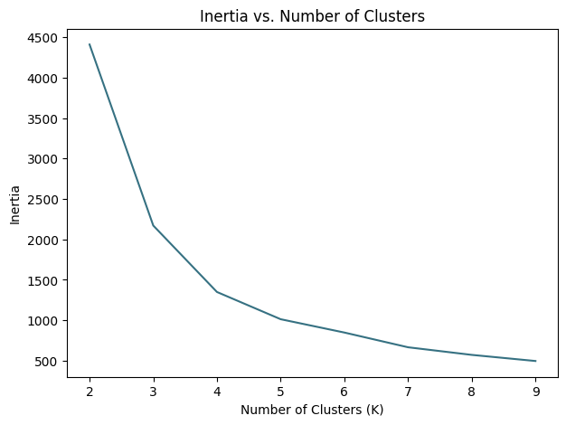

```python
X = data_scaled[cols_for_clustering]
inertia_list = []
for K in range(2,10):
    inertia = KMeans(n_clusters=K, random_state=7).fit(X).inertia_
    inertia_list.append(inertia)
plt.figure(figsize=[7,5])
plt.plot(range(2,10), inertia_list, color=(54 / 255, 113 / 255, 130 / 255))
plt.title("Inertia vs. Number of Clusters")
plt.xlabel("Number of Clusters (K)")
plt.ylabel("Inertia")
plt.show()
```

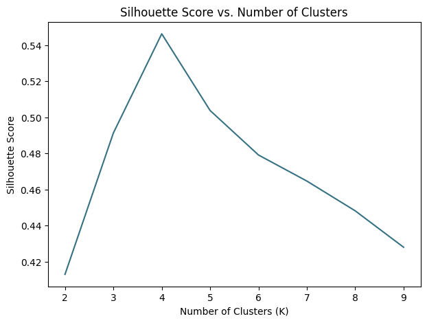

```python
from sklearn.metrics import silhouette_score
silhouette_list = []
for K in range(2,10):
    model = KMeans(n_clusters = K, random_state=7)
    clusters = model.fit_predict(X)
    s_avg = silhouette_score(X, clusters)
    silhouette_list.append(s_avg)

plt.figure(figsize=[7,5])
plt.plot(range(2,10), silhouette_list, color=(54 / 255, 113 / 255, 130 / 255))
plt.title("Silhouette Score vs. Number of Clusters")
plt.xlabel("Number of Clusters (K)")
plt.ylabel("Silhouette Score")
plt.show()
```

```python
model = KMeans(n_clusters=4, random_state = 7)
model.fit(data_scaled[cols_for_clustering])
data_scaled['Cluster'] = model.predict(data_scaled[cols_for_clustering])
```

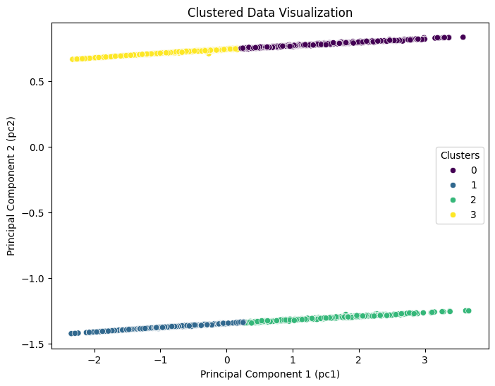

```python
plt.figure(figsize=(8, 6))
sns.scatterplot(x='pc1', y='pc2', data=data_scaled, hue='Cluster', palette='viridis')
plt.title('Clustered Data Visualization')
plt.xlabel('Principal Component 1 (pc1)')
plt.ylabel('Principal Component 2 (pc2)')
plt.legend(title='Clusters')
```

```python
data['Cluster'] = data_scaled.Cluster
data.groupby('Cluster')[cols_for_clustering].mean()
```

| Cluster | Income | MntTotal | In_relationship |
| --- | --- | --- | --- |
| 0 | 71846.901235 | 1149.742504 | 1.0 |
| 1 | 37332.339956 | 150.761589 | 0.0 |
| 2 | 72059.439394 | 1167.306061 | 0.0 |
| 3 | 37892.819883 | 158.463158 | 1.0 |

## Mean consumption of different product types by cluster¶

```python
cols_mnt = ['MntTotal', 'MntRegularProds','MntWines', 'MntFruits', 'MntMeatProducts', 'MntFishProducts', 'MntSweetProducts', 'MntGoldProds']
mnt_data = data.groupby('Cluster')[cols_mnt].mean().reset_index()
mnt_data.head()
```

|  | Cluster | MntTotal | MntRegularProds | MntWines | MntFruits | MntMeatProducts | MntFishProducts | MntSweetProducts | MntGoldProds |
| --- | --- | --- | --- | --- | --- | --- | --- | --- | --- |
| 0 | 0 | 1149.742504 | 1078.716049 | 624.382716 | 52.700176 | 342.162257 | 75.615520 | 54.881834 | 71.026455 |
| 1 | 1 | 150.761589 | 125.662252 | 85.450331 | 7.832230 | 38.774834 | 10.971302 | 7.732892 | 25.099338 |
| 2 | 2 | 1167.306061 | 1092.893939 | 617.148485 | 55.324242 | 361.278788 | 77.703030 | 55.851515 | 74.412121 |
| 3 | 3 | 158.463158 | 133.962573 | 92.046784 | 7.640936 | 39.438596 | 11.423392 | 7.913450 | 24.500585 |

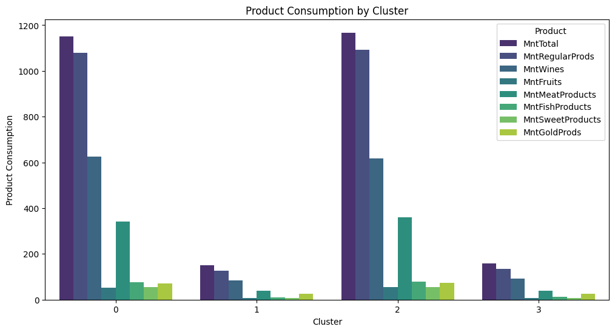

```python
melted_data = pd.melt(mnt_data, id_vars="Cluster", var_name="Product", value_name="Consumption")
plt.figure(figsize=(12, 6))
sns.barplot(x="Cluster", y="Consumption", hue="Product", data=melted_data, ci=None, palette="viridis")
plt.title("Product Consumption by Cluster")
plt.xlabel("Cluster")
plt.ylabel("Product Consumption")
plt.xticks(rotation=0)
plt.legend(title="Product", loc="upper right")

plt.show()
```

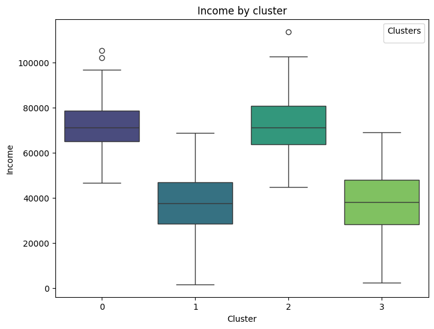

```python
plt.figure(figsize=(8, 6))
sns.boxplot(x='Cluster', y='Income', data=data, palette='viridis')
plt.title('Income by cluster')
plt.xlabel('Cluster')
plt.ylabel('Income')
plt.legend(title='Clusters')
```

Cluster 0: High value customers in relationship (either married or together)¶ This cluster represents 26% of the customer base These customers have high income and they are in a relationship

Cluster 1: Low value single customers This cluster represents 21% of the customer base These customers have low income and they are single

Cluster 2: High value single customers This cluster represents 15% of the customer base These customers have high income and they are single

Cluster 3: Low value customers in relationship This cluster represents 39% of the customer base These customers have low income and they are in a relationship